# HW_7

2024-02-15

### Function Creation

```r
nll.fun.nb <- function(k,r, x, t) {
  nll <- -sum(dnbinom(x = x,size=k, mu =r * t, log = T))
  return(nll)
}
```

### 1

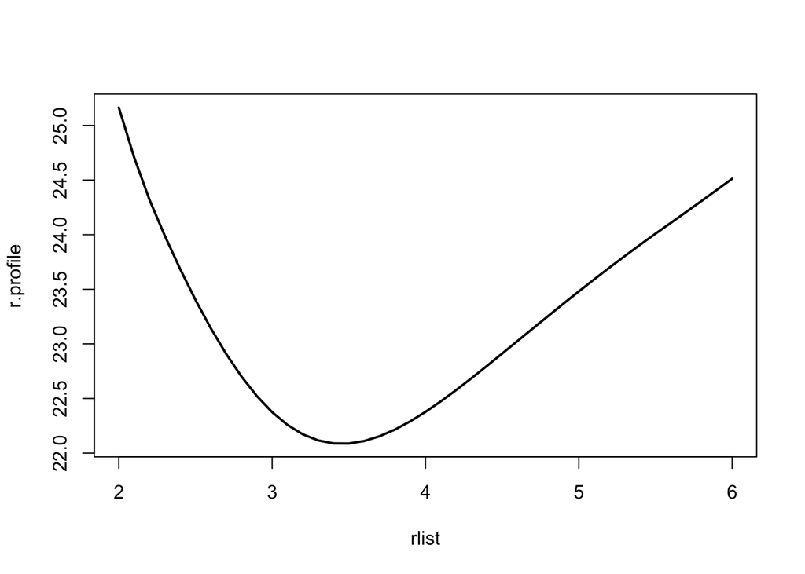

```r
x <- c(47, 43, 27, 47, 95)
t <- 15
rlist <- seq(2,6,0.1)
klist <- seq(3,10,0.1)
nll <- matrix(data = NA, nrow=length(rlist), ncol=length(klist))
for (i in 1:length(rlist)){
  r <- rlist[i]
  for (j in 1:length(klist)){
    k <-klist[j]
    nll[i,j] <- nll.fun.nb(k,r,x,t)
  }
}

r.profile <- apply(X = nll, MARGIN = 1, FUN=min)
plot(rlist, r.profile, type = "l", lwd = 2)
```

```r
min(r.profile)
```

```
## [1] 22.08819
```

```r
r.profile
```

```
##  [1] 25.16405 24.70718 24.31983 23.98970 23.68553 23.40258 23.14274 22.90809
##  [9] 22.70083 22.52265 22.37489 22.25807 22.17215 22.11640 22.08913 22.08819
## [17] 22.11091 22.15418 22.21509 22.29056 22.37773 22.47410 22.57753 22.68580
## [25] 22.79762 22.91151 23.02630 23.14124 23.25566 23.36906 23.48085 23.59077
## [33] 23.69894 23.80460 23.90810 24.00941 24.10837 24.20806 24.30874 24.41031
## [41] 24.51265
```

```r
# min nll is element 16 in r.profile, so it's element 16 in rlist

rlist[16]
```

```
## [1] 3.5
```

```r
#value of r that maximizes likelihood is 3.5

confintnb <- min(r.profile)+1.92
r.profile
```

```
##  [1] 25.16405 24.70718 24.31983 23.98970 23.68553 23.40258 23.14274 22.90809
##  [9] 22.70083 22.52265 22.37489 22.25807 22.17215 22.11640 22.08913 22.08819
## [17] 22.11091 22.15418 22.21509 22.29056 22.37773 22.47410 22.57753 22.68580
## [25] 22.79762 22.91151 23.02630 23.14124 23.25566 23.36906 23.48085 23.59077
## [33] 23.69894 23.80460 23.90810 24.00941 24.10837 24.20806 24.30874 24.41031
## [41] 24.51265
```

```r
# index values for confidence interval looking at r list are 4 and 35
rlist[4]
```

```
## [1] 2.3
```

```r
rlist[35]
```

```
## [1] 5.4
```

```r
#confidence interval is between 2.3 and 5.4, much wider than last time
```

### 2

The confidence interval was much smaller in the poisson distribution, ranging from 3.1 to 3.9. The confidence interval for the negative binomial was from 2.3 to 5.4, MUCH wider.

### 3

Allowing for patchiness in the negative binomial also allows for a wider range of potential values and more randomness in the overall population that might not be fully captured by the original data. Negative binomial functions are generally more conservative than poisson functions are in defining a tight range of probability values, allowing for greater variation. Greater variation generally leads to a wider interval that contains 95% of the (potential) data (95% confidence interval), hence why the negative binomial interval was wider than that of the poisson.

### 4

I would say if you want to be conservative and avoid overdispersion as much as possible, I would use the negative binomial distribution to estimate densities. That way, you’re way more likely to estimate a density that reflects the chaos of reality, which is generally what you’re trying to do with a model (faithfully represent reality). However, if for some reason you don’t need to capture a ton of uncertainty in the r parameter when you’re modeling, maybe you’re estimating densities in experimental plots or something, then the poisson will get you where you need to go.